# Lab book: ML outputs (vector), spike proteins

Liam Brierley (University of Liverpool)  
2020-06-09

**Summary of host group data represented:**

Table 1: CoV spike sequences, CoV species represented per host group before downsampling

| outcome | n_sequences | n_species |
| --- | --- | --- |
| swine | 2061 | 27 |
| human | 1661 | 15 |
| aves | 527 | 24 |
| camel | 323 | 7 |
| bovid | 135 | 19 |
| carnivore | 130 | 49 |
| yinbat | 97 | 48 |
| rodent | 89 | 24 |
| yangbat | 72 | 49 |
| primate | 5 | 2 |

Table 1: CoV spike sequences, CoV species represented per host group after downsampling (modelled data)

| outcome | n_sequences | n_species |
| --- | --- | --- |
| swine | 221 | 27 |
| aves | 210 | 24 |
| human | 210 | 15 |
| camel | 204 | 7 |
| bovid | 135 | 19 |
| carnivore | 130 | 49 |
| yinbat | 97 | 48 |
| rodent | 89 | 24 |
| yangbat | 72 | 49 |

Table 1: Raw probabilities of host group

| aves | bovid | camel | carnivore | human | rodent | swine | yangbat | yinbat |
| --- | --- | --- | --- | --- | --- | --- | --- | --- |
| 0.154 | 0.099 | 0.149 | 0.095 | 0.154 | 0.065 | 0.162 | 0.053 | 0.071 |

Table 1: n host taxonomic levels represented total among modelled data

| class_name | order_name | family_name | genus_name | species_name |
| --- | --- | --- | --- | --- |
| 2 | 12 | 33 | 59 | 90 |

**Summary of virus data represented AFTER HOST DOWNSAMPLING (to VIRUS DOWNSAMPLE?):**

Table 2: CoV spike sequences, host groups/sequences represented per CoV species after host downsampling

| childtaxa_name | aves | bovid | camel | carnivore | human | rodent | swine | yangbat | yinbat | total |
| --- | --- | --- | --- | --- | --- | --- | --- | --- | --- | --- |
| Middle East respiratory syndrome-related coronavirus | 0 | 0 | 170 | 0 | 52 | 0 | 0 | 3 | 0 | 225 |
| Porcine epidemic diarrhea virus | 0 | 0 | 0 | 0 | 0 | 0 | 175 | 0 | 0 | 175 |
| Infectious bronchitis virus | 169 | 0 | 0 | 0 | 0 | 0 | 0 | 0 | 0 | 169 |
| Bovine coronavirus | 0 | 103 | 0 | 0 | 0 | 0 | 0 | 0 | 0 | 103 |
| Severe acute respiratory syndrome coronavirus 2 | 0 | 0 | 0 | 0 | 100 | 0 | 0 | 0 | 0 | 100 |
| Feline coronavirus | 0 | 0 | 0 | 39 | 0 | 0 | 0 | 0 | 0 | 39 |
| Human coronavirus OC43 | 0 | 0 | 0 | 0 | 29 | 0 | 0 | 0 | 0 | 29 |
| Bat coronavirus | 0 | 0 | 0 | 0 | 0 | 0 | 0 | 16 | 12 | 28 |
| Canine coronavirus | 0 | 0 | 0 | 23 | 0 | 0 | 0 | 0 | 0 | 23 |
| SARS coronavirus MA15 | 0 | 0 | 0 | 0 | 0 | 20 | 0 | 0 | 0 | 20 |
| SARS coronavirus MA15 ExoN1 | 0 | 0 | 0 | 0 | 0 | 20 | 0 | 0 | 0 | 20 |
| Camel alphacoronavirus | 0 | 0 | 17 | 0 | 0 | 0 | 0 | 0 | 0 | 17 |
| 229E-related bat coronavirus | 0 | 0 | 0 | 0 | 0 | 0 | 0 | 0 | 16 | 16 |
| Porcine deltacoronavirus | 1 | 0 | 0 | 0 | 0 | 0 | 14 | 0 | 0 | 15 |
| Turkey coronavirus | 15 | 0 | 0 | 0 | 0 | 0 | 0 | 0 | 0 | 15 |
| Bat SARS-like coronavirus | 0 | 0 | 0 | 0 | 0 | 0 | 0 | 0 | 14 | 14 |
| Yak coronavirus | 0 | 14 | 0 | 0 | 0 | 0 | 0 | 0 | 0 | 14 |
| Rodent coronavirus | 0 | 0 | 0 | 0 | 0 | 12 | 0 | 0 | 0 | 12 |
| Human coronavirus NL63 | 0 | 0 | 0 | 0 | 10 | 0 | 0 | 0 | 0 | 10 |

MERS/SARS and the livestock/companion animal CoVs overrepresented. All other CoVs *(238)* have < 10 sequences. Could downsample to 10, or 20? Or basically downsample host-virus combinations which is perhaps what I should have done to begin with?

This does explain (and above would resolve) frequent misclassification of human MERS sequences as camel..

Do I need to check variation within MERS seqs from humans and camels though? Are they widely variable or similar? No other inflated virus has multiple host groups.

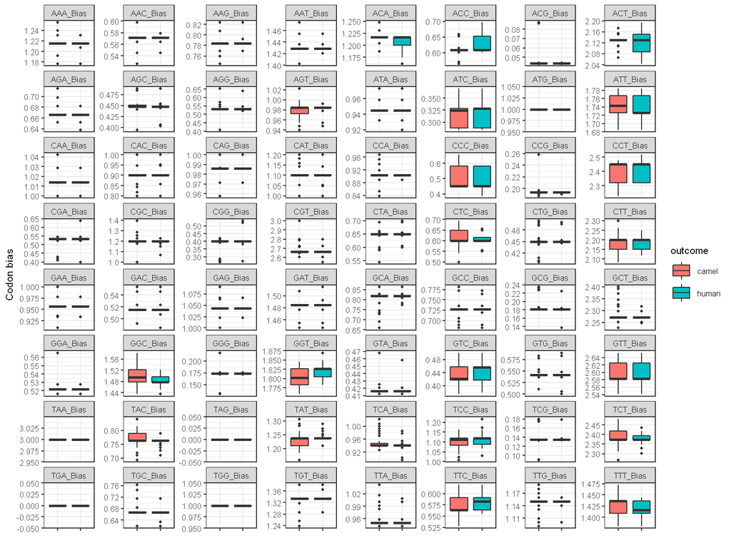

**ML options:** Use stop codons set to *TRUE*.

**Parameters from grid search, SVM:**

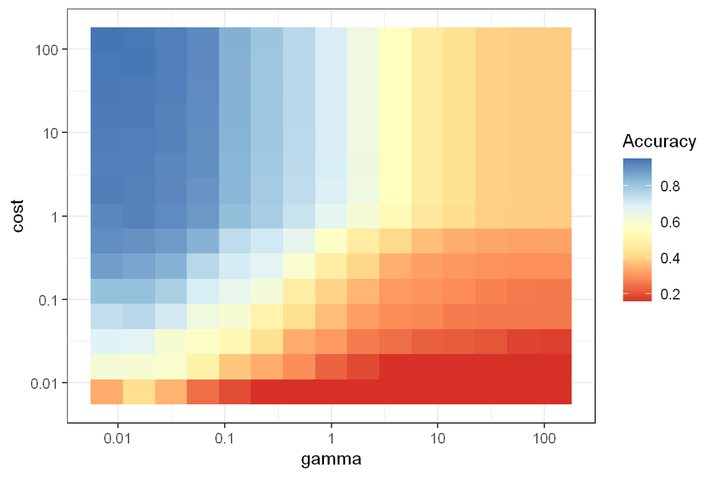

*Low gamma, high cost gives best accuracy*

**Parameters from grid search, RF**:

[interactive chart not shown]

*Low nodesize best, but accuracy indifferent to mtry, ntree*

**Confusion matrices, multiclass AUC:**

Table 3: Diagnostics, SVM

| Accuracy | Kappa | AccuracyLower | AccuracyUpper | AccuracyNull | AccuracyPValue | McnemarPValue |
| --- | --- | --- | --- | --- | --- | --- |
| 0.943 | 0.935 | 0.913 | 0.966 | 0.161 | 0 | NaN |

Table 3: Confusion matrix, SVM

|  | aves | bovid | camel | carnivore | human | rodent | swine | yangbat | yinbat |
| --- | --- | --- | --- | --- | --- | --- | --- | --- | --- |
| aves | 51 | 0 | 0 | 0 | 0 | 0 | 0 | 0 | 0 |
| bovid | 0 | 33 | 1 | 0 | 0 | 0 | 0 | 0 | 0 |
| camel | 0 | 0 | 49 | 0 | 10 | 0 | 0 | 0 | 0 |
| carnivore | 0 | 0 | 0 | 30 | 0 | 0 | 0 | 0 | 0 |
| human | 0 | 0 | 1 | 1 | 42 | 0 | 0 | 0 | 0 |
| rodent | 0 | 0 | 0 | 0 | 0 | 22 | 0 | 0 | 0 |
| swine | 1 | 0 | 0 | 1 | 0 | 0 | 54 | 0 | 0 |
| yangbat | 0 | 0 | 0 | 0 | 0 | 0 | 0 | 12 | 0 |
| yinbat | 0 | 0 | 0 | 0 | 0 | 0 | 0 | 4 | 23 |

```
[1] 0.9941057
```

Table 3: Diagnostics, RF

| Accuracy | Kappa | AccuracyLower | AccuracyUpper | AccuracyNull | AccuracyPValue | McnemarPValue |
| --- | --- | --- | --- | --- | --- | --- |
| 0.955 | 0.949 | 0.927 | 0.975 | 0.161 | 0 | NaN |

Table 3: Confusion matrix, RF

|  | aves | bovid | camel | carnivore | human | rodent | swine | yangbat | yinbat |
| --- | --- | --- | --- | --- | --- | --- | --- | --- | --- |
| aves | 50 | 0 | 0 | 0 | 0 | 0 | 0 | 0 | 0 |
| bovid | 0 | 33 | 2 | 0 | 0 | 0 | 0 | 0 | 0 |
| camel | 0 | 0 | 46 | 0 | 4 | 0 | 0 | 0 | 0 |
| carnivore | 0 | 0 | 0 | 32 | 0 | 1 | 0 | 0 | 0 |
| human | 0 | 0 | 3 | 0 | 48 | 0 | 0 | 0 | 0 |
| rodent | 0 | 0 | 0 | 0 | 0 | 21 | 0 | 0 | 0 |
| swine | 1 | 0 | 0 | 0 | 0 | 0 | 54 | 0 | 0 |
| yangbat | 1 | 0 | 0 | 0 | 0 | 0 | 0 | 14 | 1 |
| yinbat | 0 | 0 | 0 | 0 | 0 | 0 | 0 | 2 | 22 |

```
[1] 0.9943992
```

**Misclassified sequences:**

Table 4: SVM

|  | childtaxa_name | accessionversion | outcome | pred_class |
| --- | --- | --- | --- | --- |
| 2 | Porcine deltacoronavirus | MK248485.1 | aves | swine |
| 106 | Middle East respiratory syndrome-related coronavirus | MF598669.1 | camel | human |
| 136 | Bovine coronavirus isolate Alpaca | DQ915164.2 | camel | bovid |
| 148 | SARS coronavirus CS21 | DQ514531.1 | carnivore | human |
| 164 | Canine coronavirus | JN856008.2 | carnivore | swine |
| 197 | Middle East respiratory syndrome-related coronavirus | MG011350.1 | human | camel |
| 198 | Middle East respiratory syndrome-related coronavirus | KT374052.1 | human | camel |
| 199 | Middle East respiratory syndrome-related coronavirus | KT806008.1 | human | camel |
| 200 | Middle East respiratory syndrome-related coronavirus | KT805989.1 | human | camel |
| 201 | Middle East respiratory syndrome-related coronavirus | KT805977.1 | human | camel |
| 203 | Middle East respiratory syndrome-related coronavirus | KF600647.1 | human | camel |
| 204 | Middle East respiratory syndrome-related coronavirus | KF600645.1 | human | camel |
| 205 | Middle East respiratory syndrome-related coronavirus | KF600644.1 | human | camel |
| 207 | Middle East respiratory syndrome-related coronavirus | KF600612.1 | human | camel |
| 208 | Human betacoronavirus 2c EMC/2012 | JX869059.2 | human | camel |
| 303 | Bat coronavirus | KY783849.1 | yangbat | yinbat |
| 307 | BtMs-AlphaCoV/GS2013 | KJ473810.1 | yangbat | yinbat |
| 311 | Chaerephon bat coronavirus/Kenya/KY22/2006 | HQ728486.1 | yangbat | yinbat |
| 312 | Miniopterus bat coronavirus/Kenya/KY27/2006 | HQ728484.1 | yangbat | yinbat |

Table 4: RF

|  | childtaxa_name | accessionversion | outcome | pred_class |
| --- | --- | --- | --- | --- |
| 2 | Porcine deltacoronavirus | MK248485.1 | aves | swine |
| 6 | Duck coronavirus | KM454473.1 | aves | yangbat |
| 92 | Dromedary camel coronavirus HKU23 | MN514970.1 | camel | bovid |
| 98 | Middle East respiratory syndrome-related coronavirus | MG923469.1 | camel | human |
| 103 | Middle East respiratory syndrome-related coronavirus | MF598693.1 | camel | human |
| 135 | Middle East respiratory syndrome-related coronavirus | KJ477102.1 | camel | human |
| 136 | Bovine coronavirus isolate Alpaca | DQ915164.2 | camel | bovid |
| 197 | Middle East respiratory syndrome-related coronavirus | MG011350.1 | human | camel |
| 199 | Middle East respiratory syndrome-related coronavirus | KT806008.1 | human | camel |
| 201 | Middle East respiratory syndrome-related coronavirus | KT805977.1 | human | camel |
| 204 | Middle East respiratory syndrome-related coronavirus | KF600645.1 | human | camel |
| 222 | Rodent coronavirus | KY370044.1 | rodent | carnivore |
| 303 | Bat coronavirus | KY783849.1 | yangbat | yinbat |
| 307 | BtMs-AlphaCoV/GS2013 | KJ473810.1 | yangbat | yinbat |
| 314 | Rousettus aegyptiacus bat coronavirus 229E-related | MN611517.1 | yinbat | yangbat |

**Variable importance (RF only):**

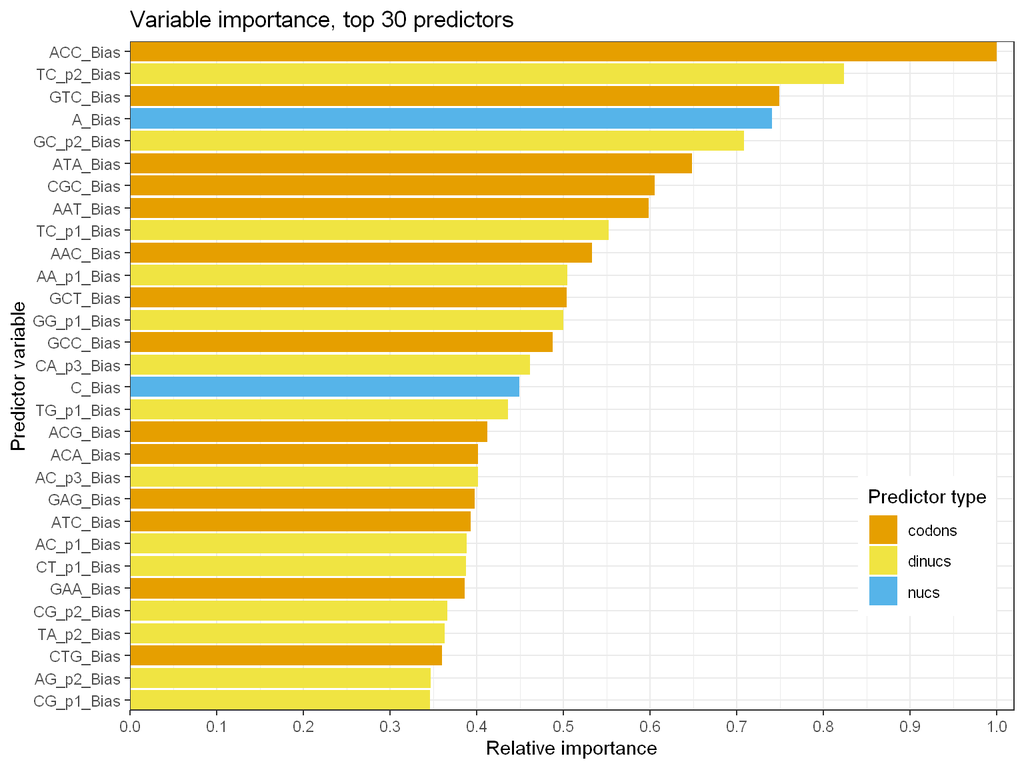

Mixed, though few p3 dinucleotides. STOP codons rank at *64, 113, 114* of *114* variables - not as informative when considering multiple host categories (or sequence host metadata?)

**Partial dependence (RF only):**

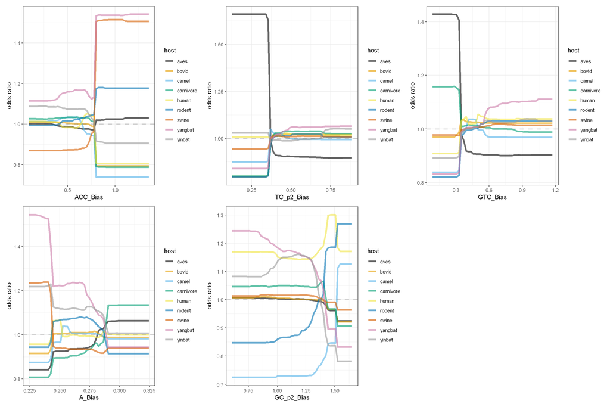